# Promoter.Rmd

| no | team_name | project_title | project_year | wiki_page |
| --- | --- | --- | --- | --- |
| 1 | Tongji_China | Seek Heme And Reflect cracK (SHARK) | 2020 | https://2020.igem.org/Team:Tongji_China |

| no | part_id | part_name | part_type | team_id |
| --- | --- | --- | --- | --- |
| 1 | BBa_R0051 | Promoter (lambda cI regulated) | Promoter | 1 |
| 2 | BBa_K3475007 | Prm- RBS RFP Ter / cl lam R0051-B0034-mRFP1 E1010-B0015 | Project | 1 |

#Plasmid Construction of Heme Biosensor System 1. Standard PCR to obtain target fragments

2. 1% Agarose Gel Electrophoresis to identify PCR products
3. DpnI Restriction Enzyme Digestion to eliminate templates
4. Gel DNA Extraction and Purification or PCR clean-up to purify PCR products
5. Homologous Recombination
6. Bacterial Transformation
7. Colony PCR
8. Bacterial glycerol stock
9. Plasmid Extraction

#Protocols of repoter protein expression (Characterization of HBS-BAS)

1. Inoculate E.coli-pHBS-cI-pA1C-R0051-RFP-I12007-GFP, E.coli-HrtO-cI-pA1C-R0051-RFP-I12007-GFP, E.coli-pSB1C3-K608010, E.coli-pSB1K3-J04450 and E.coli-wildtype in LB medium. Resuscitate it in incubator at 37℃ and 200 rpm, overnight.
2. Inoculate the bacterial solution into a 96-well plate in the manner of 100 μL/well, with 3 groups in parallel. LB medium was used as the control group.
3. Measure the OD600 and fluorescence intensity (GFP: ex: 475 nm, em: 515 nm; RFP: ex:588 nm, em: 635 nm) of the plates by the Microplate spectrophotometer.
4. The following formula was used to calculate the relative fluorescence intensity of bacteria, using LB medium as blank.

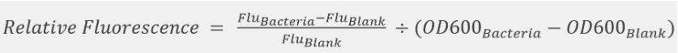